# Use corporate design with RMarkdown

Contribution to the DEiVHERSS competition 2023

Hartstein, J., Tcypina, A., Fabian, G.

# Preliminary remarks

This document template should help you with starting RMarkdown (Allaire et al. 2023) reporting at DZHW. The focus of this template is the use of corporate colours in plots for all outputs, and the corporate MS Word document template for reports.

To use an MS Word template with RMarkdown, you just state it in the YAML header - to make the document perfect, some editing in Word will likely still be required[^1]. Please note, that the template must be in your working directory (i.e. probably the folder, in which your .rmd document is located).

As a corporate template for html documents has not yet been made available, the html version of this template is limited to color schemes and the logo up right. The logo must be located in your working directory as “DZHW_Logo.jpg”.

For reasons of self-containment, the figures use the gss_cat dataset from the package forcats (Wickham 2023). For analyses and visualisations, we use the tidyverse (Wickham et al. 2019) and ggplot2 (Wickham 2016).

Please note, that the code chunks (the computations) are hidden, but you can use the download button (which appears up right in the html version of this template) to access the full source code of this document.

If you have questions or remarks for improvement, please contact hartstein@dzhw.eu

# 1 Simple barchart (one variable)

You can start with a simple bar chart. To play around, see what happens, when you comment or uncomment lines.

In HTML, also the image alt text is embedded. Unfortunately, this does not yet work with the MS Word output.

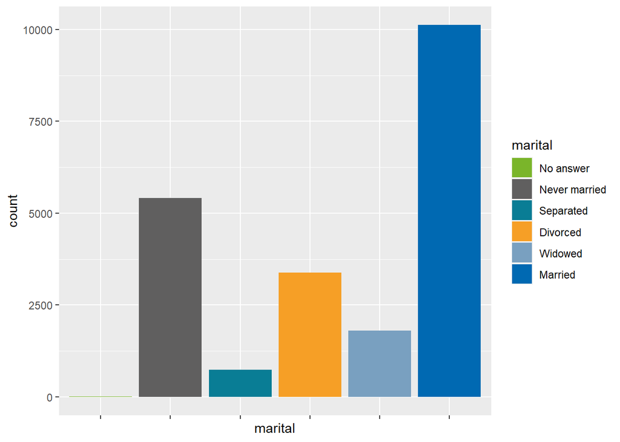

# 2 Ordered barchart (one variable)

The bars are ordered by size and axis title as well as legend are hidden to get a cleaner look.

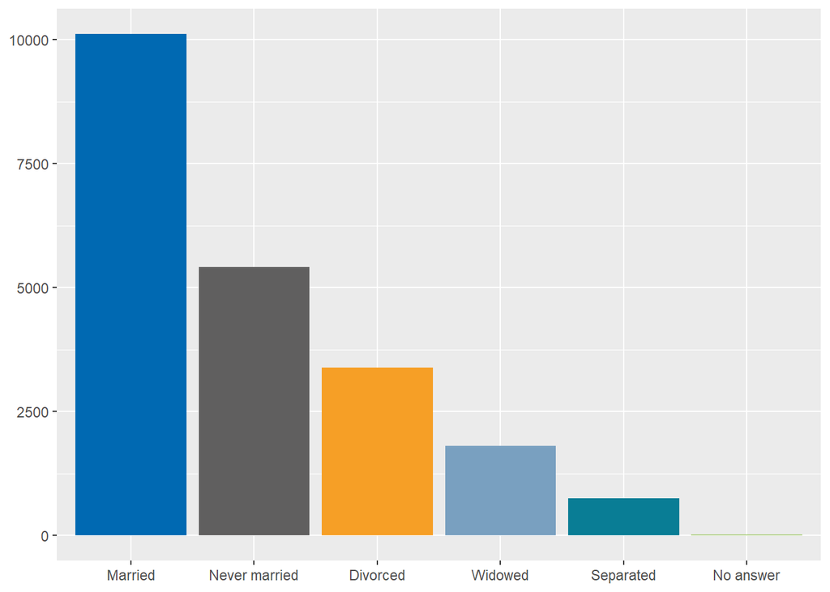

# 3 Another ordered barchart (one variable)

If the variable you are counting in the bars has long names (read: almost always), we recommend a horizontal bar chart. Also, you can decide to only use one colour from the corporate colour palette.

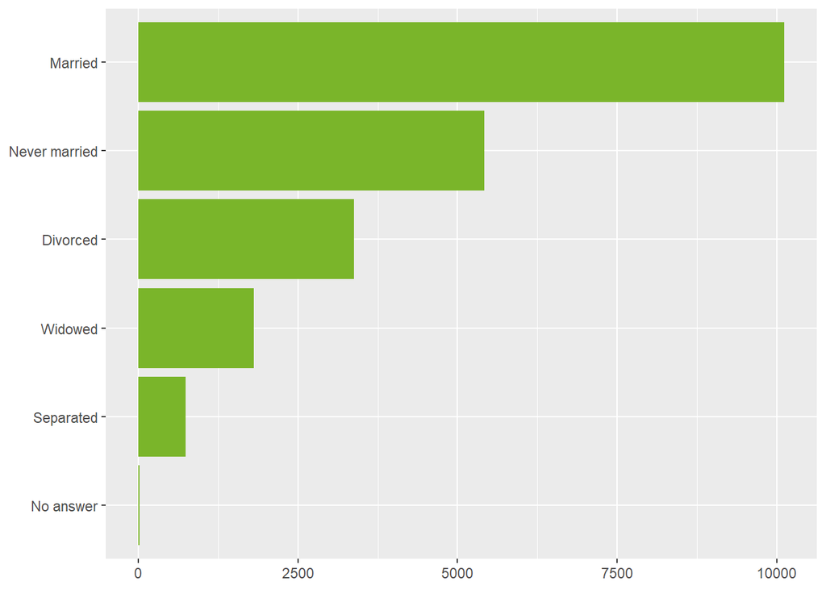

# 4 Stacked barplot (two variables)

To show relations between two variables, you can also use a stacked bar chart. For this use case, percentages as labels are recommended.

Please note, that legends can get difficult to print, if there are many categories in your variable. Always check, if you can aggregate or exclude levels (e.g. “No answer” and “Don’t know”) - if applicable, depending on your mission or research question.

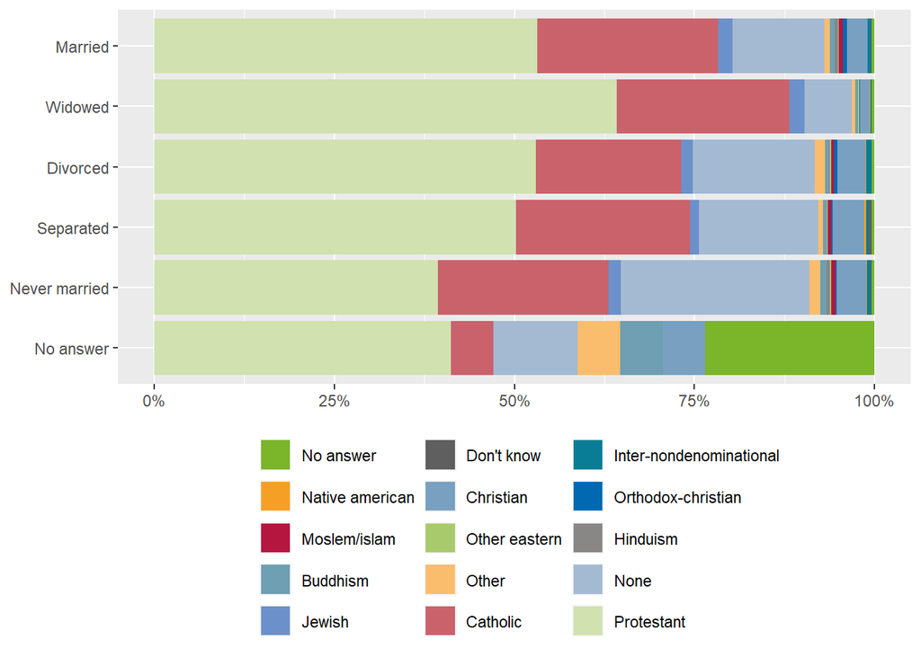

# 5 Stacked barplot wrapped in panels (three variables)

To show the relation to a third variable, you can panelize your data. Most likely you will have to adjust the number of columns and the height of the figure for facet_wrap, when using an MS Word document as output.

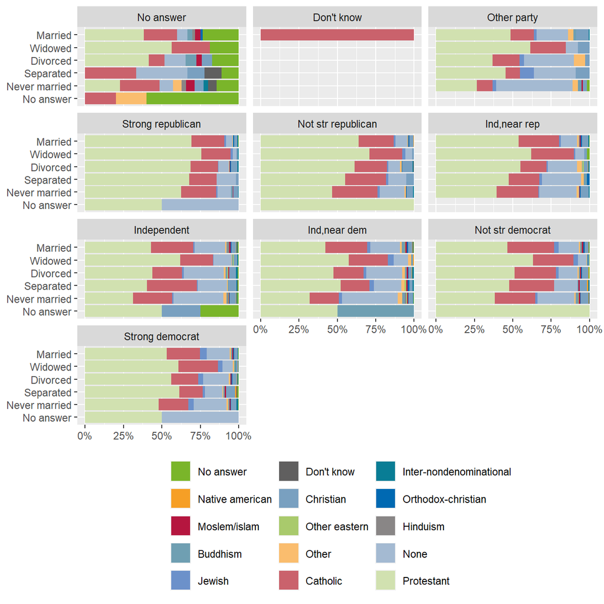

# 6 Stacked barplot in a grid (four variables)

With grid layouts, you can also show four variables - however, this does only work smoothly, if you have not too many categories. The dimensions of the grid are the categories of your third variable times categories of your fourth variable.

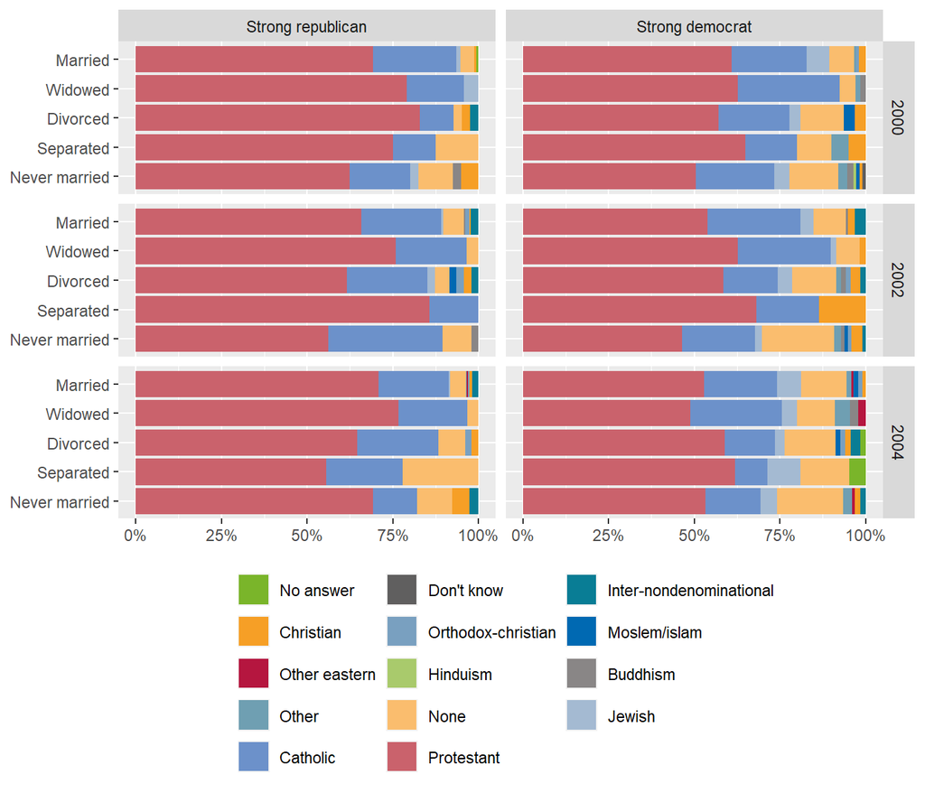

# References

Allaire, JJ, Yihui Xie, Christophe Dervieux, Jonathan McPherson, Javier Luraschi, Kevin Ushey, Aron Atkins, et al. 2023. *Rmarkdown: Dynamic Documents for r*. https://github.com/rstudio/rmarkdown.

Wickham, Hadley. 2016. *Ggplot2: Elegant Graphics for Data Analysis*. Springer-Verlag New York. https://ggplot2.tidyverse.org.

———. 2023. *Forcats: Tools for Working with Categorical Variables (Factors)*. https://CRAN.R-project.org/package=forcats.

Wickham, Hadley, Mara Averick, Jennifer Bryan, Winston Chang, Lucy D’Agostino McGowan, Romain François, Garrett Grolemund, et al. 2019. “Welcome to the tidyverse.” *Journal of Open Source Software* 4 (43): 1686. https://doi.org/10.21105/joss.01686.

[^1]: But we can hope for a Word template which is more interoperable in the future.